# Ch8: Conservation Biology of Wildebeests in the Serengeti

Jessica Couture

1/23/2019

## The “questions”:

“In this chapter we consider two questions that correspond to two periods of examination of the wildebeest population trends and sepcific questions considered important in those periods. First - in 1978 when the herd first exceeded 1 million individiuals, there was serious **concern about the population if a series of dry years should occur.** Second,  
- in the early 1990s, population size had leveled but was subject to considerable illegal harvest. **Managers were interested in determining the level of harvest and the potential response of the herd to increases in such uncontrolled harvest.**  
Answering these questions shows how likelihood methods can be used to select between different models, how different sources of data can be combined through models based on observation uncertainty and how data may be informative of not depending upon the particular questions we ask.”

```r
library(tidyverse)
```

```r
library(ggplot2)
```

# Logistic model

We begin with the logistic model, equation 8.2, with observation uncertainty and use the census data available in 1978.
$$N_{t+1}=N_t+rN_t\left(1-\frac{N_t}{K}\right)$$
Use equation 8.4 to determine the best values of *r* and *K*:
$$L_t=log(\sigma_t)+\frac{1}{2}log(2\pi)+\frac{(N_{obs,t}-N_{t})^2}{2\sigma_{t}^2}$$

1. Input census data up to 1978 (means and standard deviations)

```
## [1] 1960 1989
```

```
## # A tibble: 6 x 3
##    year estPop estSD
##   <dbl>  <dbl> <dbl>
## 1  1960     NA    NA
## 2  1961    263    NA
## 3  1962     NA    NA
## 4  1963    357    NA
## 5  1964     NA    NA
## 6  1965    439    NA
```

2. Input starting estimates of the parameters *r*, *K*,*$N_1$*

```r
r=0.05
K=2.0*10^9
N1=300
```

3. Find the values fo the parameters that minimize the negaitve log-likelihood by:
1. predicting the values of $N_t$ from equation 8.2

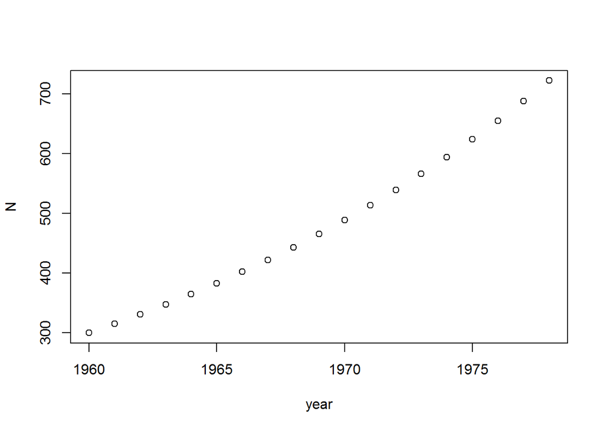

```r
Nt<-as.numeric()
Nt[1]<-N1
for(i in 1:nrow(wld1)){
  Nt[i+1]<-Nt[i]+r*Nt[i]*(1-(Nt[i]/K))
}
ntDf<-data.frame(year=wld1$year,
                 N=Nt[1:nrow(wld1)])

plot(ntDf)
```

2. calculating the negative log-likelihood using equation 8.4 for years in which census data are available

```r
wld1Dat<-wld1%>%
  filter(!is.na(estPop)) %>%
  filter(!is.na(estSD)) %>%
  left_join(.,ntDf) %>%
  mutate(Lt=log(estSD)+(1/2)*log(2*pi)+(((estPop-N)^2)/((2*estSD)^2)))
```

3. summing the negative log likelihoods over all years

```r
sumL<-sum(wld1Dat$Lt)
```

4. minimizing the total sum of negative log likelihoods over r and K

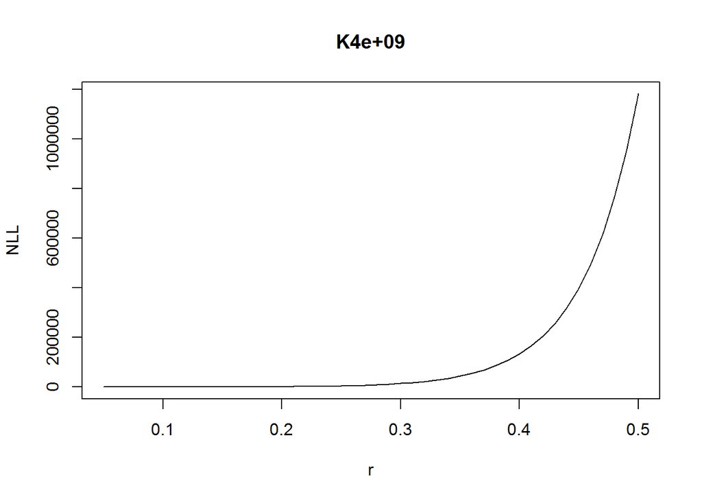

```r
wld1Dat2<-wld1%>%
  filter(!is.na(estPop)) %>%
  filter(!is.na(estSD))

#funcitonalize nll calcs:
nllCalc<-function(rR,Kk){

  Nt<-as.numeric()
  Nt[1]<-N1

  for(i in 1:nrow(wld1)){
    Nt[i+1] <- Nt[i] + rR*Nt[i]*(1-(Nt[i]/Kk))
  }
  ntDf<-data.frame(year=wld1$year,
                 N=Nt[1:nrow(wld1)])

dat<-wld1Dat2%>%
  left_join(.,ntDf) %>%
  mutate(Lt=log(estSD)+(1/2)*log(2*pi)+(((estPop-N)^2)/((2*estSD)^2)))
  nll<-sum(dat$Lt)
  return(nll)
  }

# create vectors for r and K
rVec<-seq(r,0.5,by=0.01)
KVec<-seq(1.0*10^9,4.0*10^9,by=2.5*10^8)

# dataframe for r and K values
nlls<-data.frame(r=rVec,
                  k1=NA,
                  k2=NA,
                  k3=NA,
                  k4=NA,
                  k5=NA,
                  k6=NA,
                  k7=NA,
                  k8=NA,
                  k9=NA,
                  k10=NA,
                  k11=NA,
                  k12=NA,
                  k13=NA)
colnames(nlls)<-c("r",sapply(KVec,function(x) paste("K",x,sep="")))

for(i in 1:length(KVec)){
  forVec<-sapply(rVec,function(x) nllCalc(x,KVec[i]))
  nlls[,i+1]<-forVec[1:length(forVec)]
}

minDims<-which(nlls==min(nlls[,2:ncol(nlls)]),arr.ind=T)

nll_r=nlls[minDims[1],1]
nll_k=colnames(nlls)[minDims[2]]

plot(nlls[,minDims[2]]~nlls$r,data=nlls,type="l",main=colnames(nlls)[minDims[2]],ylab="NLL",xlab="r")
```

# Life History Model

Given the data available in 1978, there is a better chance of understanding what is likely to happen if rainfall decreases after 1978 if we use the information contained in the calf survival and adult survival data. To do this, we confront the life history model (with parameters *a, b, f,* and *g*) with the census, calf survival, and adult mortality data using the following code:  
1. Input rainfall, census, calf survival, and adult mortality data and $N_1$ up to 1978 2. Input starting parameters for *a, b, f*, and *g*.

```r
wld2<-wld%>%
  filter(year<1979)

a=1.1
b=1.1
f=1.1
g=1.1
```

3. Find the values of the parameters that minimize the negaitve log likelihood by:
1. Predicting the values of $N_t$ and calf and adult survival fron equation 8.10:
   $$N_{t+1}=(s_{adult,t})N_t+(s_{calf,t})B_t$$
   $$N_{obs,t}=N_t+V_t$$
   where $s_{adult,t}=\frac{gF_t}{f+F_t}$, $F_t=\frac{1.25R_t*Area}{N_t}$, and $s_{calf,t}=\frac{aF_t}{b+F_t}$, and $B_t=0.4N_t$

```r
  A=1000000

expPop<-function(rain,N){

  Tt=1.25*rain
  Ft=(Tt*A)/Nt
  Bt=0.4*N

  sA=(g*Ft)/(f+Ft)
}
```